# Happiness and Economy: A Comparative Analysis of Life Satisfaction and Economic Indicators

## Exploring the Data Science Lifecycle

#### Kshiti Deshpande

- Introduction
- 1. Data Collection
- 2. Data Cleaning
- 3. Exploratory Data Analysis
  - 3.1 Overview of Dataset
  - 3.2 Distribution of Happiness scores
  - 3.3 Happiness Scores by Year
  - 3.4 GDP per Capita vs Happiness scores
  - 3.5 Correlation Heatmap of Key Indicators
  - 3.6 Relationships Between Happiness and Other Indicators
- 4. Model - ML, Hypothesis testing, Analysis
  - 4.1 Preparing Features and Target
  - 4.2 Linear Regression
  - 4.3 Random Forest Regression
  - 4.4 Combined Interpretation
  - 4.5 Hypothesis Testing
  - 4.6 Visualizations
- 5. Conclusions

## Introduction

Happiness is often viewed as a personal emotion, but at a national scale it becomes a powerful indicator of social progress and quality of life. Governments, researchers, and international organizations increasingly rely on happiness metrics to understand how people experience their daily lives. The World Happiness Report, supported by Gallup surveys and academic research, provides a consistent way to measure life evaluation through the Cantril ladder question. This simple question asks people to place themselves on a scale from zero to ten, where zero represents the worst possible life and ten represents the best possible life. The responses offer insight into the lived reality of millions of people across the world.

At the same time, economic indicators continue to dominate discussions about development and policy. Measures such as GDP per capita, GDP growth, and income levels shape how countries are compared and evaluated. Economic growth is frequently assumed to be a key driver of well being, yet the relationship between money and happiness is complex. Wealth can provide security, opportunity, and access to resources, but it does not guarantee social trust, good health, or a strong community. There are countries with relatively modest GDP levels that report very high life satisfaction, and there are wealthy countries that still struggle with low well being outcomes.

This topic is highly relevant to data science. It connects quantitative measurement with social interpretation and demonstrates how data driven insights can inform policy decisions. Happiness data is collected through large scale surveys, economic indicators come from national reporting systems, and both require careful cleaning, merging, and statistical treatment. The analysis in this project uses exploratory data analysis, hypothesis testing, and machine learning models to reveal patterns in how happiness and economic variables relate to each other.

## Why is this important?

Studying happiness is important for two main reasons. First, it reflects access to meaningful opportunities, social safety, and the quality of relationships and institutions. Second, many governments prioritize economic growth, but growth does not always translate into greater well being. By analyzing happiness alongside economic indicators, we can identify when income contributes to life satisfaction and when it does not.

This tutorial also demonstrates how data science can address social questions. Readers will learn to merge diverse datasets, handle missing values, create intuitive visualizations, and perform statistical analyses in a reproducible and interpretable way.

In summary, understanding the relationship between happiness and economic performance requires careful data work and thoughtful interpretation. This project provides a comprehensive walkthrough of real-world data analysis, revealing insights with direct implications for public policy, global development, and the broader study of human well being.

## Part 1: Data Collection

Understanding global happiness requires integrating information from multiple trusted international datasets. Since this tutorial compares life satisfaction with economic indicators, we need data sources that measure both subjective well being and objective economic conditions across countries and years.

For happiness data, the most widely used source is the World Happiness Report, which compiles survey based life evaluations from the Gallup World Poll. The dataset contains each country’s average life satisfaction score and contributing factors such as GDP per capita, social support, healthy life expectancy, freedom of choice, generosity, and perceptions of corruption. These scores form the foundation of global well being analysis and are frequently used in social science research.

For economic indicators, international organizations provide standardized and reliable measurements. The World Bank Open Data API offers global GDP per capita, GDP growth, inflation, unemployment, and other macroeconomic indicators for nearly all countries. Combining these measures with the happiness scores allows us to investigate how economic conditions correspond with self reported life satisfaction.

The goal of this section is to collect, import, and combine these datasets into a single structured dataframe. We will use happiness data from the World Happiness Report (2020 - 2024) and economic data from the World Bank. The datasets differ in structure, naming conventions, and availability of years, so proper data harmonization will be essential in the next step.

```python
# Core libraries for data analysis
import pandas as pd
import numpy as np
import wbdata
import matplotlib.pyplot as plt
import seaborn as sns

# Set plotting style for consistency
sns.set_theme(style="whitegrid")
```

```python
# Load happiness data from World Happiness Report
# WHR dataset link has been provided at the end of this tutorial

files = ["2020.csv", "2021.csv", "2022.csv", "2023.csv", "2024.csv"]
years = [2020, 2021, 2022, 2023, 2024]

dfs = []
for file, year in zip(files, years):
    df = pd.read_csv(file)
    df["Year"] = year
    dfs.append(df)

happiness_df = pd.concat(dfs, ignore_index=True)
happiness_df.rename(columns={"Country name": "Country"}, inplace=True)
happiness_df.head()
```

|  | Country | Happiness Rank | Happiness score | Upperwhisker | Lowerwhisker | Economy (GDP per Capita)\t | Social support | Healthy life expectancy | Freedom to make life choices | Generosity | Perceptions of corruption | Year |
| --- | --- | --- | --- | --- | --- | --- | --- | --- | --- | --- | --- | --- |
| 0 | Finland | 1 | 7.81 | 7.87 | 7.75 | 1.29 | 1.50 | 0.96 | 0.66 | 0.16 | 0.48 | 2020 |
| 1 | Denmark | 2 | 7.65 | 7.71 | 7.58 | 1.33 | 1.50 | 0.98 | 0.67 | 0.24 | 0.50 | 2020 |
| 2 | Switzerland | 3 | 7.56 | 7.63 | 7.49 | 1.39 | 1.47 | 1.04 | 0.63 | 0.27 | 0.41 | 2020 |
| 3 | Iceland | 4 | 7.50 | 7.62 | 7.39 | 1.33 | 1.55 | 1.00 | 0.66 | 0.36 | 0.14 | 2020 |
| 4 | Norway | 5 | 7.49 | 7.56 | 7.42 | 1.42 | 1.50 | 1.01 | 0.67 | 0.29 | 0.43 | 2020 |

```python
# Load World Bank Data from WBData API

# Indicator for GDP per capita
gdp_indicator = {"NY.GDP.PCAP.KD": "GDP_per_capita"}

countries = wbdata.get_countries()
data_dates = (pd.to_datetime("2020-01-01"), pd.to_datetime("2024-12-31"))

gdp_df = wbdata.get_dataframe(gdp_indicator, date=data_dates)
gdp_df = gdp_df.reset_index().rename(columns={"country": "Country", "date": "Year"})

gdp_df.head()
```

|  | Country | Year | GDP_per_capita |
| --- | --- | --- | --- |
| 0 | Africa Eastern and Southern | 2024 | 1416.250369 |
| 1 | Africa Eastern and Southern | 2023 | 1412.625384 |
| 2 | Africa Eastern and Southern | 2022 | 1421.797169 |
| 3 | Africa Eastern and Southern | 2021 | 1409.040699 |
| 4 | Africa Eastern and Southern | 2020 | 1383.724119 |

We will be merging the two datasets - World Happiness Report and World Bank data for comparitive analysis of Happiness score and Economic indicators

```python
# Convert Year to int for easy merging
happiness_df["Year"] = happiness_df["Year"].astype(int)
gdp_df["Year"] = gdp_df["Year"].astype(int)

# Merge on Country and Year
merged_df = pd.merge(
    happiness_df,
    gdp_df,
    on=["Country", "Year"],
    how="left"
)

merged_df.head()
```

|  | Country | Happiness Rank | Happiness score | Upperwhisker | Lowerwhisker | Economy (GDP per Capita)\t | Social support | Healthy life expectancy | Freedom to make life choices | Generosity | Perceptions of corruption | Year | GDP_per_capita |
| --- | --- | --- | --- | --- | --- | --- | --- | --- | --- | --- | --- | --- | --- |
| 0 | Finland | 1 | 7.81 | 7.87 | 7.75 | 1.29 | 1.50 | 0.96 | 0.66 | 0.16 | 0.48 | 2020 | 44690.980110 |
| 1 | Denmark | 2 | 7.65 | 7.71 | 7.58 | 1.33 | 1.50 | 0.98 | 0.67 | 0.24 | 0.50 | 2020 | 55934.555595 |
| 2 | Switzerland | 3 | 7.56 | 7.63 | 7.49 | 1.39 | 1.47 | 1.04 | 0.63 | 0.27 | 0.41 | 2020 | 84637.013294 |
| 3 | Iceland | 4 | 7.50 | 7.62 | 7.39 | 1.33 | 1.55 | 1.00 | 0.66 | 0.36 | 0.14 | 2020 | 52641.723492 |
| 4 | Norway | 5 | 7.49 | 7.56 | 7.42 | 1.42 | 1.50 | 1.01 | 0.67 | 0.29 | 0.43 | 2020 | 75287.205953 |

At this stage, the merged dataset will still contain inconsistencies:

- Country naming differences
- Missing economic values for certain years
- Irregular formatting

These issues will be addressed in the Data Processing section.

## Part 2: Data Cleaning

Before any meaningful analysis can be performed, it is essential to clean and standardize the dataset. Real-world data often contains missing values, inconsistencies in country names, or incorrect data types that can affect visualizations, correlations, and modeling results.

In this tutorial, the following cleaning steps are performed:

1. Drop unnecessary columns (Happiness Rank, Upperwhisker, Lowerwhisker, WHR GDP).
2. Handle missing values: impute or drop rows with missing critical columns.
3. Normalize country names for consistency.
4. Ensure numeric types for calculations.
5. Remove duplicates for Country-Year combinations.

By performing these steps, we ensure that the dataset is clean, consistent, and ready for exploratory data analysis and modeling.

```python
# Inspect merged dataset
print("Merged dataset shape:", merged_df.shape)
merged_df.info()
```

```
Merged dataset shape: (728, 13)
<class 'pandas.core.frame.DataFrame'>
RangeIndex: 728 entries, 0 to 727
Data columns (total 13 columns):
 #   Column                        Non-Null Count  Dtype
---  ------                        --------------  -----
 0   Country                       728 non-null    object
 1   Happiness Rank                728 non-null    int64
 2   Happiness score               728 non-null    float64
 3   Upperwhisker                  728 non-null    float64
 4   Lowerwhisker                  728 non-null    float64
 5   Economy (GDP per Capita)	     725 non-null    float64
 6   Social support                725 non-null    float64
 7   Healthy life expectancy       724 non-null    float64
 8   Freedom to make life choices  725 non-null    float64
 9   Generosity                    725 non-null    float64
 10  Perceptions of corruption     725 non-null    float64
 11  Year                          728 non-null    int64
 12  GDP_per_capita                615 non-null    float64
dtypes: float64(10), int64(2), object(1)
memory usage: 74.1+ KB
```

The describe() function helps by giving a quick statistical overview of the numerical features, including counts, means, standard deviations, and value ranges. This summary helps us understand data distribution, detect potential outliers, and spot inconsistencies or unusual patterns early. Overall, it provides a fast health check of the dataset before deeper analysis or modeling.

```python
# Inspect statistical summary of the dataset
merged_df.describe()
```

|  | Happiness Rank | Happiness score | Upperwhisker | Lowerwhisker | Economy (GDP per Capita)\t | Social support | Healthy life expectancy | Freedom to make life choices | Generosity | Perceptions of corruption | Year | GDP_per_capita |
| --- | --- | --- | --- | --- | --- | --- | --- | --- | --- | --- | --- | --- |
| count | 728.000000 | 728.000000 | 728.000000 | 728.000000 | 725.000000 | 725.000000 | 724.000000 | 725.000000 | 725.000000 | 725.000000 | 728.000000 | 615.000000 |
| mean | 73.401099 | 5.524740 | 5.640658 | 5.408864 | 1.200348 | 1.026796 | 0.541228 | 0.526359 | 0.162572 | 0.143833 | 2021.956044 | 16222.461511 |
| std | 42.232618 | 1.113797 | 1.095239 | 1.133577 | 0.474080 | 0.333321 | 0.223931 | 0.156044 | 0.088944 | 0.121611 | 1.421293 | 21279.845728 |
| min | 1.000000 | 1.721000 | 1.775000 | 1.667000 | 0.000000 | 0.000000 | 0.000000 | 0.000000 | 0.000000 | 0.000000 | 2020.000000 | 255.078218 |
| 25% | 37.000000 | 4.770000 | 4.905000 | 4.648500 | 0.880000 | 0.811000 | 0.380000 | 0.430000 | 0.099000 | 0.060000 | 2021.000000 | 2088.435421 |
| 50% | 73.000000 | 5.583000 | 5.689500 | 5.482000 | 1.240000 | 1.070000 | 0.555500 | 0.548000 | 0.148000 | 0.110000 | 2022.000000 | 6278.785514 |
| 75% | 110.000000 | 6.325500 | 6.430750 | 6.214250 | 1.536000 | 1.292000 | 0.703000 | 0.639000 | 0.215000 | 0.180000 | 2023.000000 | 20914.176152 |
| max | 153.000000 | 7.842000 | 7.904000 | 7.780000 | 2.209000 | 1.620000 | 1.140000 | 0.863000 | 0.570000 | 0.587000 | 2024.000000 | 110873.185245 |

```python
# Count missing values
merged_df.isnull().sum()
```

```
Country                           0
Happiness Rank                    0
Happiness score                   0
Upperwhisker                      0
Lowerwhisker                      0
Economy (GDP per Capita)\t        3
Social support                    3
Healthy life expectancy           4
Freedom to make life choices      3
Generosity                        3
Perceptions of corruption         3
Year                              0
GDP_per_capita                  113
dtype: int64
```

```python
# Strip whitespace from column names
merged_df.columns = merged_df.columns.str.strip()

# Drop unnecessary columns
drop_cols = ["Happiness Rank", "Upperwhisker", "Lowerwhisker", "Economy (GDP per Capita)"]
merged_clean = merged_df.drop(columns=drop_cols)
```

Handling missing values involves identifying and addressing gaps in a dataset so the analysis or model can operate on complete, consistent information. Missing data can arise from survey non-responses, measurement errors, or incomplete records, and if left untreated, it can distort patterns or weaken model performance. Proper handling—whether by removing affected rows or imputing with statistical estimates—helps preserve the integrity of the dataset. It reduces bias, prevents errors during model training, and ensures that results remain meaningful and comparable.

```python
# Handle missing values
# Critical columns: Country, Year, Happiness score, GDP_per_capita
merged_clean = merged_clean.dropna(subset=["Country", "Year", "Happiness score", "GDP_per_capita"])

# For other numeric columns, impute median
numeric_cols = ["Social support", "Healthy life expectancy",
                "Freedom to make life choices", "Generosity", "Perceptions of corruption"]
for col in numeric_cols:
    merged_clean[col] = merged_clean[col].fillna(merged_clean[col].median())
```

```python
# Normalize country names
merged_clean["Country"] = merged_clean["Country"].str.strip()
country_rename = {
    "United States of America": "United States",
    "Korea, Republic of": "South Korea",
    "Czech Republic": "Czechia",
}
merged_clean["Country"] = merged_clean["Country"].replace(country_rename)
```

Ensuring numeric data types is essential because many statistical methods and machine-learning algorithms require numerical inputs to perform mathematical operations. Incorrect types, such as numbers stored as strings can cause errors, miscalculations, or prevent models from learning properly. Converting values to proper numeric formats ensures accurate computations, efficient processing, and reliable model performance.

```python
# Ensure numeric types
for col in ["Happiness score", "GDP_per_capita"] + numeric_cols:
    merged_clean[col] = pd.to_numeric(merged_clean[col], errors='coerce')
```

Dropping duplicates removes repeated records that can otherwise distort patterns in the data and give certain observations more influence than they should. It helps ensure that analyses and models are based on unique, unbiased information rather than inflated counts. It improves data quality, prevents skewed results, and supports more accurate model training.

```python
# Drop duplicates
merged_clean = merged_clean.drop_duplicates(subset=["Country", "Year"])
```

```python
# Check final shape and missing values
print("Cleaned dataset shape:", merged_clean.shape)
print(merged_clean.isnull().sum())
```

```
Cleaned dataset shape: (615, 9)
Country                         0
Happiness score                 0
Social support                  0
Healthy life expectancy         0
Freedom to make life choices    0
Generosity                      0
Perceptions of corruption       0
Year                            0
GDP_per_capita                  0
dtype: int64
```

## Part 3: Exploratory Data Analysis

Exploratory Data Analysis helps us understand the structure, patterns, and relationships within the merged 2020–2024 dataset before building any models. The goal is to identify trends in happiness over time, understand how economic indicators distribute across countries, and examine how different social and governance factors interact with the happiness score.

Since all missing values have been handled and the cleaned dataset is ready, EDA helps validate data quality and uncover the most relevant features for modeling.

In this section, we will:

1. Examine the distribution of happiness scores globally.
2. Explore the relationship between GDP per capita and happiness.
3. Look at other drivers of happiness like social support, health, and freedom.
4. Observe temporal trends across 2020–2024.

### 3.1 Overview of Dataset

```python
# Inspect cleaned dataset
merged_clean.info()
```

```
<class 'pandas.core.frame.DataFrame'>
Index: 615 entries, 0 to 725
Data columns (total 9 columns):
 #   Column                        Non-Null Count  Dtype
---  ------                        --------------  -----
 0   Country                       615 non-null    object
 1   Happiness score               615 non-null    float64
 2   Social support                615 non-null    float64
 3   Healthy life expectancy       615 non-null    float64
 4   Freedom to make life choices  615 non-null    float64
 5   Generosity                    615 non-null    float64
 6   Perceptions of corruption     615 non-null    float64
 7   Year                          615 non-null    int64
 8   GDP_per_capita                615 non-null    float64
dtypes: float64(7), int64(1), object(1)
memory usage: 48.0+ KB
```

The cleaned dataset contains 615 rows and 9 columns, covering five years of global happiness data from 2020 to 2024. Each row represents a country-year observation.

```python
# Inspect statistical summary of the dataset
merged_clean.describe()
```

|  | Happiness score | Social support | Healthy life expectancy | Freedom to make life choices | Generosity | Perceptions of corruption | Year | GDP_per_capita |
| --- | --- | --- | --- | --- | --- | --- | --- | --- |
| count | 615.000000 | 615.000000 | 615.000000 | 615.000000 | 615.000000 | 615.000000 | 615.000000 | 615.000000 |
| mean | 5.602659 | 1.041576 | 0.545993 | 0.540854 | 0.164743 | 0.145914 | 2021.967480 | 16222.461511 |
| std | 1.125124 | 0.335146 | 0.221686 | 0.150721 | 0.089227 | 0.125921 | 1.435559 | 21279.845728 |
| min | 1.859000 | 0.000000 | 0.000000 | 0.000000 | 0.000000 | 0.000000 | 2020.000000 | 255.078218 |
| 25% | 4.830000 | 0.829500 | 0.387500 | 0.453500 | 0.101000 | 0.060000 | 2021.000000 | 2088.435421 |
| 50% | 5.766000 | 1.083000 | 0.562000 | 0.560000 | 0.152000 | 0.110000 | 2022.000000 | 6278.785514 |
| 75% | 6.400000 | 1.320000 | 0.706500 | 0.647000 | 0.218000 | 0.188500 | 2023.000000 | 20914.176152 |
| max | 7.842000 | 1.620000 | 1.140000 | 0.863000 | 0.570000 | 0.587000 | 2024.000000 | 110873.185245 |

This gives a first understanding of data types, ranges, and variations. For instance:

- Happiness score typically ranges between 2 and 8
- GDP per capita varies widely across countries
- Social indicators are mostly measured between 0 and 1

A quick descriptive summary helps identify extremes and potential outliers.

### 3.2 Distribution of Happiness scores

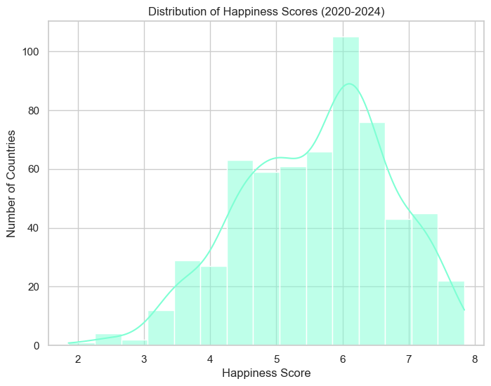

```python
plt.figure(figsize=(8,6))
sns.histplot(merged_clean["Happiness score"], bins=15, kde=True, color="aquamarine")
plt.title("Distribution of Happiness Scores (2020-2024)")
plt.xlabel("Happiness Score")
plt.ylabel("Number of Countries")
plt.show()
```

Happiness scores tend to follow a slightly left-skewed distribution, with most countries scoring between 4.5 and 6.5. Very few countries fall at the extreme high or low ends. A smaller tail extends toward the lower happiness scores, indicating fewer very low-scoring countries. This distribution will help contextualize economic and social comparisons.

### 3.3 Happiness Scores by Year

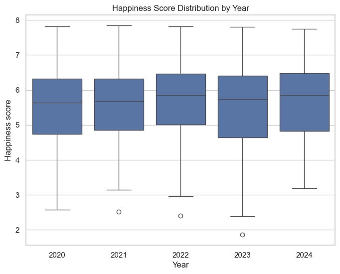

```python
plt.figure(figsize=(8,6))
sns.boxplot(data=merged_clean, x="Year", y="Happiness score")
plt.title("Happiness Score Distribution by Year")
plt.show()
```

This plot reveals year-to-year variability but no dramatic global shifts. Median happiness has remained fairly stable, suggesting that global well-being does not fluctuate sharply in the short term.

### 3.4 GDP per Capita vs Happiness Scores

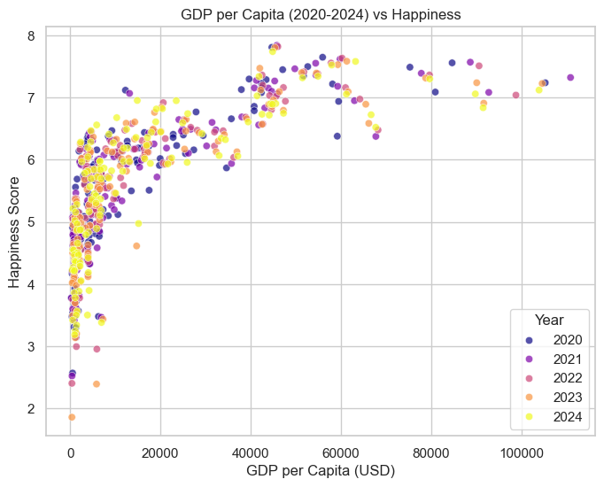

```python
plt.figure(figsize=(8,6))
sns.scatterplot(data=merged_clean,
                x="GDP_per_capita",
                y="Happiness score",
                hue="Year",
                palette="plasma",
                alpha=0.7)
plt.title("GDP per Capita (2020-2024) vs Happiness")
plt.xlabel("GDP per Capita (USD)")
plt.ylabel("Happiness Score")
plt.legend(title="Year")
plt.show()
```

A positive trend is clearly visible: countries with higher GDP per capita generally report higher happiness scores. However, the scatter is not perfectly linear, suggesting that GDP is not the sole determinant — beyond a certain threshold, other factors likely matter more.

### 3.5 Correlation Heatmap of Key Indicators

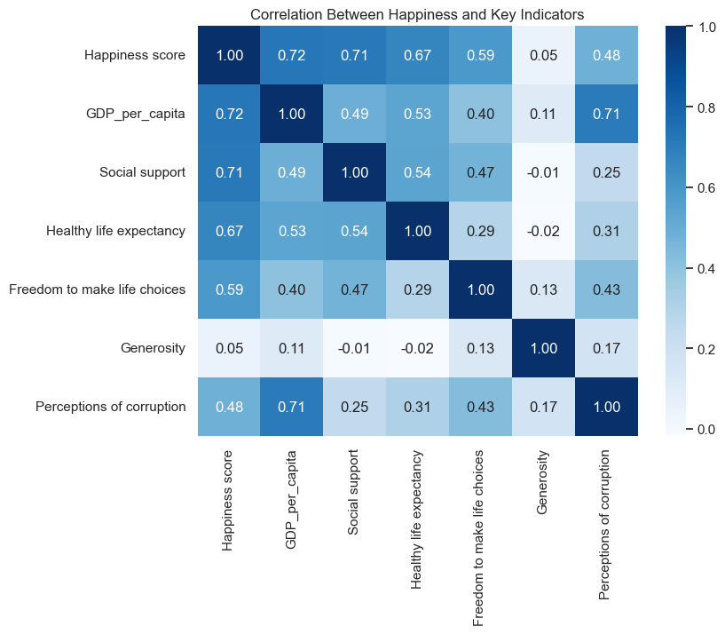

```python
# Select numeric columns for correlation
corr_cols = ["Happiness score", "GDP_per_capita", "Social support",
             "Healthy life expectancy", "Freedom to make life choices",
             "Generosity", "Perceptions of corruption"]

plt.figure(figsize=(8,6))
sns.heatmap(merged_clean[corr_cols].corr(), annot=True, fmt=".2f", cmap="Blues")
plt.title("Correlation Between Happiness and Key Indicators")
plt.show()
```

Key Insights from the Correlation Heatmap

1. Top drivers of happiness:
   - GDP per capita (0.72)
   - Social support (0.71)
   - Healthy life expectancy (0.67)
2. Moderate contributors:
   - Freedom to make life choices (0.59)
   - Perceptions of corruption (0.48)
3. Weak contributor:
   - Generosity shows almost no correlation with happiness (0.05).
4. Notable cross-variable relationships:
   - GDP and corruption perception strongly correlate (0.71).
   - Social support and life expectancy have a moderate link (0.54).
   - Wealthier countries generally show better health and lower corruption.
5. Generosity stands out as an independent variable, showing weak connections with most others.

Happiness is most strongly connected with economic well-being, social support, and health. Autonomy and institutional trust matter too, but generosity appears to have almost no direct statistical link to happiness in this dataset.

### 3.6 Relationships Between Happiness and Other Indicators

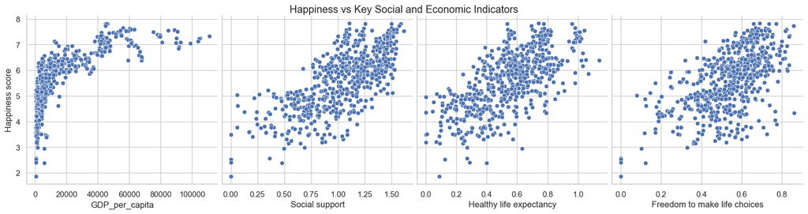

```python
# Pairplot for visual relationships
sns.pairplot(merged_clean, x_vars=["GDP_per_capita", "Social support",
                                   "Healthy life expectancy", "Freedom to make life choices",],
             y_vars=["Happiness score"], height=4, aspect=1, kind="scatter")
plt.suptitle("Happiness vs Key Social and Economic Indicators", y=1.02)
plt.show()
```

- All key social indicators show positive relationships with happiness.
- These plots suggest that multi-factor models (beyond GDP alone) will better explain happiness variation.

EDA confirms that a multi-factor analysis is appropriate for modeling happiness.

## Part 4: Model - ML, Hypothesis Testing and Analysis

After understanding the dataset through EDA, we move on to modeling the relationship between happiness and its potential determinants. This section focuses on:

- Constructing models
- Testing hypotheses
- Evaluating model performance
- Interpreting coefficients and feature importance

We use two types of models:

- A simple, interpretable Linear Regression
- A more flexible Random Forest Regressor

This combination provides both clarity and predictive strength.

### 4.1 Preparing Features and Target

We select predictors that theory and EDA support as meaningful:

```python
X = merged_clean[[
    "GDP_per_capita",
    "Social support",
    "Healthy life expectancy",
    "Freedom to make life choices",
    "Generosity",
    "Perceptions of corruption"
]]

y = merged_clean["Happiness score"]
```

We then split the data into training and testing set:

```python
from sklearn.model_selection import train_test_split

X_train, X_test, y_train, y_test = train_test_split(
    X, y, test_size=0.2, random_state=42
)
```

### 4.2 Linear Regression

Linear regression is ideal for initial modeling because it is interpretable, fast, and provides coefficients that quantify the impact of each variable.

Training the model:

```python
from sklearn.linear_model import LinearRegression
from sklearn.metrics import r2_score, mean_squared_error

lr = LinearRegression()
lr.fit(X_train, y_train)

y_pred = lr.predict(X_test)
lr_r2 = r2_score(y_test, y_pred)
lr_rmse = np.sqrt(mean_squared_error(y_test, y_pred))

print("Linear Regression R^2:", lr_r2)
print("Linear Regression RMSE:", lr_rmse)
```

```
Linear Regression R^2: 0.7498490496042107
Linear Regression RMSE: 0.5605433952539737
```

Interpreting coefficients:

```python
coef_df = pd.DataFrame({
    "Feature": X.columns,
    "Coefficient": lr.coef_
}).sort_values(by="Coefficient", ascending=False)

coef_df
```

|  | Feature | Coefficient |
| --- | --- | --- |
| 3 | Freedom to make life choices | 1.917214 |
| 2 | Healthy life expectancy | 1.318882 |
| 1 | Social support | 0.986596 |
| 0 | GDP_per_capita | 0.000019 |
| 4 | Generosity | -0.123606 |
| 5 | Perceptions of corruption | -0.536533 |

How do we interpret these coefficients? What do they mean?

- A positive coefficient means increasing that factor raises happiness.
- A negative coefficient decreases happiness.
- Large coefficients indicate strong influence.

Here,

- Freedom to make life choices, Healthy life expectancy and Social Support show strong positive relationships.
- Corruption shows a negative relationship.
- This also suggests a weak linear relationship between raw GDP and happiness.

The linear model suggests that social and personal factors (freedom, health, support) have a stronger linear association with happiness than raw economic output.

### 4.3 Random Forest Regression

Linear regression assumes linear relationships. Random Forest, however, captures:

- Non-linear patterns
- Variable interactions
- Complex decision boundaries

Training the Random Forest Regressor:

```python
from sklearn.ensemble import RandomForestRegressor

rf = RandomForestRegressor(
    n_estimators=300,
    random_state=42
)

rf.fit(X_train, y_train)
y_pred_rf = rf.predict(X_test)

rf_r2 = r2_score(y_test, y_pred_rf)
rf_rmse = np.sqrt(mean_squared_error(y_test, y_pred_rf))

print("Random Forest R^2:", rf_r2)
print("Random Forest RMSE:", rf_rmse)
```

```
Random Forest R^2: 0.8034537789146146
Random Forest RMSE: 0.4968674081150565
```

Feature Importance:

```python
feat_imp = pd.DataFrame({
    "Feature": X.columns,
    "Importance": rf.feature_importances_
}).sort_values(by="Importance", ascending=False)

feat_imp
```

|  | Feature | Importance |
| --- | --- | --- |
| 0 | GDP_per_capita | 0.769913 |
| 3 | Freedom to make life choices | 0.087399 |
| 4 | Generosity | 0.050982 |
| 1 | Social support | 0.038033 |
| 5 | Perceptions of corruption | 0.028501 |
| 2 | Healthy life expectancy | 0.025172 |

Interpretation:

Random Forest captures nonlinear relationships and feature interactions, often giving a more realistic picture of complex phenomena like well-being.

1. GDP_per_capita is overwhelmingly the most important predictor (0.77 importance).
- Unlike Linear Regression, Random Forest captures nonlinear effects, such as:
  - diminishing returns at high GDP levels
  - threshold effects for low-income countries
  - nonlinear interactions with social factors
  - This explains why GDP appears much more important here.
2. Freedom to make life choices is the second most influential predictor.
3. Generosity, Social support, and Perceptions of corruption have moderate but meaningful influence.
4. Healthy life expectancy shows the lowest importance in this nonlinear model. - But this does not mean it is unimportant. - It could be highly correlated with GDP and therefore overshadowed in the forest model.

Random Forest paints a different picture: economic strength (GDP per capita) dominates, while social factors contribute but with smaller relative weights. This contrast with the linear model highlights why it is important to use multiple modeling techniques.

### 4.4 Combined Interpretation

- Linear Regression suggests that freedom, health, and social support are most strongly associated with happiness.
- Random Forest, however, reveals that GDP per capita has a major nonlinear impact on happiness, especially among low and middle-income countries.
- This means:
  - At low income levels, increases in GDP have large effects on happiness.
  - Beyond a certain threshold, additional GDP adds little happiness.
  - Social variables still matter, but their effects are more stable and less nonlinear.

These findings are not contradictory — they highlight different sides of the same phenomenon.

This dual-model approach supports the well-known concept in happiness economics:

- Money matters most when you do not have enough.
- After basic needs are met, social and psychological factors dominate.

### 4.5 Hypothesis Testing

While exploratory data analysis and regression models reveal patterns, they do not tell us whether these patterns are statistically significant or could have occurred by chance. Hypothesis testing provides a formal, quantitative framework to answer questions such as:

- Is GDP per capita genuinely associated with happiness, or is the relationship weak/noisy?
- Are average happiness scores different across years?
- Which socio-economic factors show statistically reliable associations with happiness?

These tests strengthen the credibility of your conclusions by grounding them in statistical inference.

##### 1. GDP and Happiness

Null (H0): There is no correlation between GDP per capita and Happiness Score. Alternate (H1): There is a positive correlation between GDP per capita and Happiness Score.

##### 2. Social Support and Happiness

H0: Social support is not correlated with Happiness Score. H1: Social support is positively correlated with Happiness Score.

##### 3. Freedom to Make Life Choices and Happiness

H0: Freedom is not correlated with Happiness Score. H1: Freedom has a positive correlation with Happiness Score.

##### 4. Perceived Corruption and Happiness

H0: Perceptions of corruption are not associated with Happiness Score. H1: Corruption has a negative correlation with Happiness Score.

##### 5. Happiness Across Years (2020–2024)

H0: The mean happiness score is the same for all years. H1: At least one year has a different mean happiness score.

This requires an ANOVA test.

#### Pearson Correlation:

Pearson correlation measures the strength and direction of the linear relationship between two continuous variables. It helps determine whether changes in one variable are associated with proportional changes in another.

```python
import scipy.stats as stats

features = [
    'GDP_per_capita',
    'Social support',
    'Healthy life expectancy',
    'Freedom to make life choices',
    'Generosity',
    'Perceptions of corruption'
]

results = []

for feature in features:
    r, p = stats.pearsonr(merged_clean[feature], merged_clean['Happiness score'])
    results.append((feature, r, p))

# Convert to DataFrame
hypothesis_results = pd.DataFrame(results, columns=['Feature', 'Correlation_r', 'p_value'])
hypothesis_results
```

|  | Feature | Correlation_r | p_value |
| --- | --- | --- | --- |
| 0 | GDP_per_capita | 0.718089 | 1.418675e-98 |
| 1 | Social support | 0.714257 | 4.511235e-97 |
| 2 | Healthy life expectancy | 0.666817 | 2.478036e-80 |
| 3 | Freedom to make life choices | 0.589048 | 1.027862e-58 |
| 4 | Generosity | 0.046372 | 2.508632e-01 |
| 5 | Perceptions of corruption | 0.481597 | 4.981520e-37 |

#### ANOVA Test

A one-way ANOVA tests whether the means of three or more independent groups differ significantly. It identifies if at least one group’s average is statistically different from the others.

```python
# Group happiness scores by year
groups = [group['Happiness score'].values
          for name, group in merged_clean.groupby('Year')]

F_statistic, p_value = stats.f_oneway(*groups)

F_statistic, p_value
```

```
(np.float64(0.3395388475080884), np.float64(0.8513116023237093))
```

The p-value = 0.85 is much greater than 0.05. Therefore, we fail to reject the null hypothesis.

There is no evidence of meaningful differences in average happiness scores across the years 2020, 2021, 2022, 2023, and 2024.

Even though global events (COVID-19, inflation, war, geopolitical instability) dramatically affected many regions during these years, the overall country-level happiness averages remain statistically stable.

This aligns with research showing that:

- Happiness scores tend to be structural
- Year-to-year fluctuations are small unless major societal shifts occur
- Economic and social indicators explain more variance than time itself

### 4.6 Visualizations

#### Linear Regression Coefficients Plot

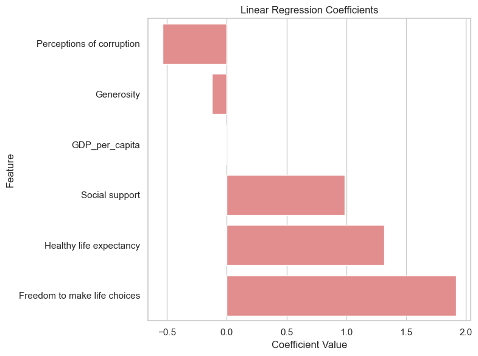

```python
coef_df = coef_df.sort_values("Coefficient", ascending=True)

plt.figure(figsize=(8,6))
sns.barplot(x="Coefficient", y="Feature", data=coef_df, color="lightcoral")
plt.title("Linear Regression Coefficients")
plt.xlabel("Coefficient Value")
plt.ylabel("Feature")
plt.tight_layout()
plt.show()
```

#### Random Forest Feature Importance Plot

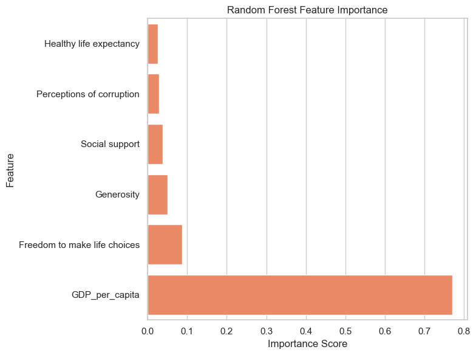

```python
imp_df = feat_imp.sort_values("Importance", ascending=True)

plt.figure(figsize=(8,6))
sns.barplot(x="Importance", y="Feature", data=imp_df, color="coral")
plt.title("Random Forest Feature Importance")
plt.xlabel("Importance Score")
plt.ylabel("Feature")
plt.tight_layout()
plt.show()
```

#### Partial Dependence Plot (Money vs Happiness)

[figure not shown]

```python
from sklearn.inspection import PartialDependenceDisplay

import warnings
warnings.filterwarnings("ignore", message=".*identical low and high ylims.*")

fig = plt.figure(figsize=(8,6))
PartialDependenceDisplay.from_estimator(
    rf, merged_clean, ["GDP_per_capita"], kind="average"
)
plt.title("Partial Dependence: GDP per Capita and Happiness")
plt.tight_layout()
plt.show()
```

```python
import folium
import requests

# Prepare dataset: one row per country
df_latest = merged_clean.sort_values("Year").groupby("Country").tail(1)
df_latest["Country"] = df_latest["Country"].replace({
    "United States": "United States of America"
})
df_map = df_latest.rename(columns={"Country": "country"}).reset_index(drop=True)

# Load geojson
url = "https://raw.githubusercontent.com/python-visualization/folium/master/examples/data/world-countries.json"
geojson_data = requests.get(url).json()

world_map = folium.Map(location=[20, 0], zoom_start=2, tiles="cartodbpositron")

# Choropleth
folium.Choropleth(
    geo_data=geojson_data,
    data=df_map,
    columns=["country", "Happiness score"],
    key_on="feature.properties.name",
    fill_color="YlGnBu",
    fill_opacity=0.8,
    line_opacity=0.3,
    nan_fill_color="white",
    legend_name="Happiness Score",
).add_to(world_map)


# Tooltips
tooltip_df = df_map.set_index("country")

for feature in geojson_data["features"]:
    country_name = feature["properties"]["name"]

    if country_name in tooltip_df.index:
        row = tooltip_df.loc[country_name]

        tooltip_html = f"""
        <b>{country_name}</b><br>
        Happiness Score: {row['Happiness score']:.2f}<br>
        GDP per Capita: {row['GDP_per_capita']:.2f}<br>
        Social Support: {row['Social support']:.2f}<br>
        Healthy Life Expectancy: {row['Healthy life expectancy']:.2f}<br>
        Freedom: {row['Freedom to make life choices']:.2f}<br>
        Generosity: {row['Generosity']:.2f}<br>
        Corruption Perception: {row['Perceptions of corruption']:.2f}<br>
        Year: {int(row['Year'])}
        """

        folium.GeoJson(
            feature,
            tooltip=tooltip_html
        ).add_to(world_map)

world_map
```

Make this Notebook Trusted to load map: File -> Trust Notebook

[interactive chart not shown]

To complement the statistical models, we have created an interactive global visualization using Folium. This choropleth map displays each country shaded according to its happiness score, allowing readers to explore spatial patterns in well being. By hovering over a country, the viewer can see additional contextual features such as GDP per capita, social support, healthy life expectancy, and freedom of choice. This map helps illustrate clear regional trends, such as the cluster of high happiness in the Nordic countries and lower levels across parts of Africa and South Asia. The interactivity of the map makes the analysis more engaging and provides an intuitive way to connect numerical results with geographic context.

## Part 5: Conclusions

Overall, the study demonstrates that understanding happiness requires a holistic perspective. Economic growth alone does not guarantee well-being; instead, happiness emerges from the combined influence of prosperity, social trust, health systems, and personal freedoms.

### Limitations

Despite yielding meaningful insights, this study has several limitations:

1. Data Availability and Consistency
   - Happiness data and economic indicators were sourced from multiple datasets across different years, which may vary in methodology. Some indicators had missing values, requiring imputation. While median-imputation is practical, it may smooth out real variation.
2. Limited Feature Set
   - The analysis used a curated subset of available variables. Important drivers of happiness—such as inequality, cultural factors, mental health prevalence, and political stability were not included due to dataset constraints.
3. Cross-Sectional Nature
   - Each year’s data represent a snapshot of countries, not a longitudinal follow-up of the same individuals. Thus, the relationships reflect national-level correlations rather than causal mechanisms.
4. Simplified Modeling Assumptions
   - While Random Forests capture nonlinearities, more advanced models (e.g., gradient boosting, multilevel models) could provide deeper insights. Additionally, hyperparameter tuning was kept minimal.
5. Cultural and Regional Differences
   - Happiness measurements rely on self-reported scores. Cultural norms about expressing satisfaction vary widely across regions, potentially biasing cross-country comparisons.

### Future Scope

There are multiple directions to extend and deepen this analysis:

1. Incorporating More Socioeconomic Indicators
   - Adding variables such as inequality (Gini index), unemployment rates, literacy levels, health expenditure, and political stability could lead to richer models.
2. Time-Series or Panel Data Modeling
   - Using panel regression or mixed-effects models over multiple years would allow tracking the effect of economic trends on happiness more causally.
3. Machine Learning Extensions
   - Future work could experiment with: • XGBoost or LightGBM • Neural networks for multivariate prediction • Clustering countries based on happiness profiles • SHAP values for model interpretability
4. Regional and Cultural Sub-Analysis
   - Analyzing happiness within continents, income groups, or cultural clusters may reveal more nuanced patterns hidden in global averages.
5. Policy Simulation
   - Scenario modeling could explore how changes in GDP, corruption reduction, or improved health outcomes might affect happiness scores over time.

### Real-World Implications

This analysis has several meaningful implications for policymakers, governments, and international organizations:

1. Rethinking Development Priorities
   - Economic growth alone is insufficient for improving life satisfaction. Investments in healthcare, social trust, safety nets, and civil freedoms may yield larger gains in well-being.
2. Enhancing Public Policy Design
   - Countries with lower GDP but strong social structures can serve as models for more sustainable, people-centered development strategies.
3. Benchmarking and Accountability
   - Happiness metrics offer a complementary perspective to traditional economic indicators, encouraging governments to evaluate success beyond GDP.
4. Evidence-Based Resource Allocation
   - Understanding which factors most strongly influence happiness helps governments allocate funding more effectively—toward mental health, community building, or public health initiatives.
5. Global Comparison and Collaboration
   - International organizations can use happiness findings to guide cross-country partnerships, equitable development goals, and global well-being initiatives.

Ultimately, well-being is both a personal and societal outcome, and evidence-driven analysis like this can help shape policies that prioritize a better quality of life for people across the world.

### References

**Data Sources**

1. [World Happiness Report (2020-2024)](https://www.kaggle.com/datasets/samithsachidanandan/world-happiness-report-2020-2024/data)
2. [World Bank Open Data](https://wbdata.readthedocs.io/en/stable/)

**Helpful Reading Material**

1. Clark, Andrew E., and Claudia Senik. "Will GDP growth increase happiness in developing countries?." 8th Conference AFD-EUDN. Measure for Measure: How well do we Measure Development?. Vol. 3. AFD, 2010.
2. Bublyk, Myroslava, et al. "Sustainable Development by a Statistical Analysis of Country Rankings by the Population Happiness Level." COLINS. 2022.
3. Kahneman, Daniel, and Angus Deaton. "High income improves evaluation of life but not emotional well-being." Proceedings of the national academy of sciences 107.38 (2010): 16489-16493.